# Module 10. Missing data and dropout

Slides

## What this module covers

- Kinds of missing data and how to describe them
- MCAR, MAR, MNAR, and what data can and cannot show
- When the mixed model of all observed data is valid
- Why LOCF and complete cases fail
- Multiple imputation for longitudinal data, Rubin’s rules
- Delta adjustment and tipping points
- Informative visit timing

**Simulated data**

All examples use simulated data from fictional studies. Results illustrate methods; they are not empirical findings.

# Describing missing data

## Three kinds of missing data

- **Intermittent:** a missed visit, then return
- **Dropout (monotone):** leave and never return
- **Missing covariates:** a baseline or time-varying covariate not recorded

Death or a terminal event is different: the outcome no longer exists.

## The WALK pattern

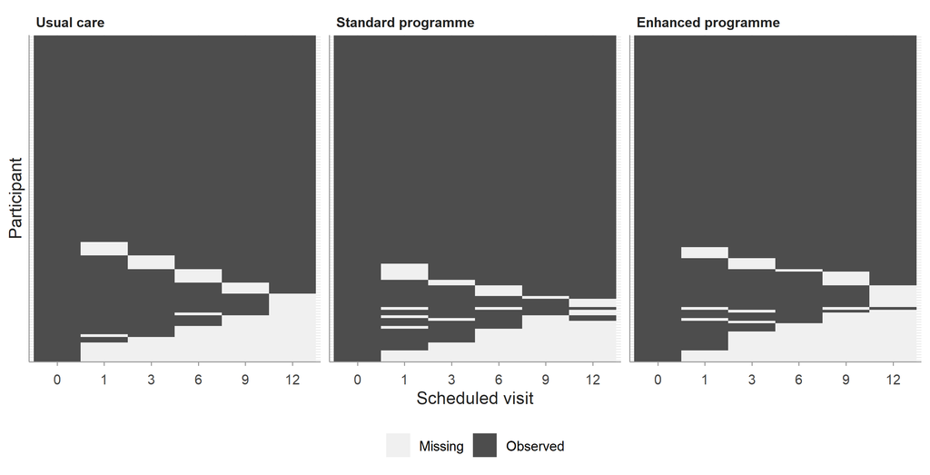

## Dropout is related to observed SBP

| term | estimate | se | lower | upper | p |
| --- | --- | --- | --- | --- | --- |
| (Intercept) | 0.053 | 0.206 | 0.035 | 0.079 | 0.000 |
| prev_sbp10 | 1.317 | 0.090 | 1.103 | 1.573 | 0.002 |
| armSP | 0.795 | 0.307 | 0.435 | 1.450 | 0.454 |
| armEP | 1.176 | 0.286 | 0.672 | 2.061 | 0.570 |

Odds of dropout × 1.32 per 10 mmHg higher last observed SBP: **not MCAR**.

# Mechanisms

## MCAR, MAR, MNAR

| Mechanism | Missingness depends on | WALK example |
| --- | --- | --- |
| MCAR | nothing in the outcomes | broken BP monitor, job move |
| MAR | observed data only | withdrawn after a **recorded** high SBP |
| MNAR | unobserved values | stops coming because BP has risen **since** last visit |

## Simulation: impose each mechanism on the complete data

- 200 dropout patterns per mechanism, about a third drop out
- Dropout driven by change in SBP since baseline:
  - MAR: at the last **observed** visit
  - MNAR: at the visit about to be **missed**
- Bias measured against the complete-data estimate

## Only the mixed model survives MAR; nothing survives MNAR

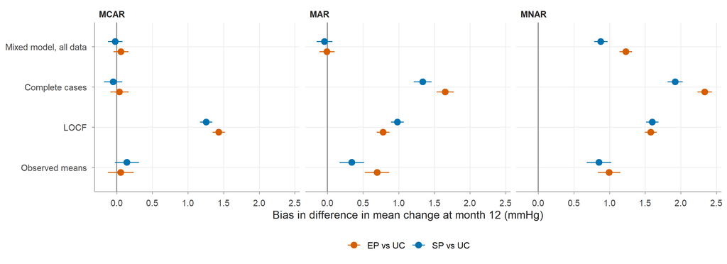

## The data cannot tell MAR from MNAR

- Observed data can show **not MCAR**
- Every MNAR model has an MAR counterpart that fits the observed data equally well
- In the simulation, dropout is related to the last observed change under **both** MAR and MNAR

MAR is an assumption, justified by study knowledge and checked by sensitivity analysis.

## Try it

Workbook exercises 1 and 2: describe the pattern, classify scenarios, fit the dropout model.

# The mixed model under MAR

## Ignorability: the likelihood factorises

$$f(\mathbf{y}_i^{o}, \mathbf{r}_i \mid \boldsymbol\theta, \boldsymbol\psi) = f(\mathbf{y}_i^{o} \mid \boldsymbol\theta) \times P(\mathbf{r}_i \mid \mathbf{y}_i^{o}, \boldsymbol\psi)$$

Valid if:

1. MAR
2. $\boldsymbol\theta$ and $\boldsymbol\psi$ separable (1 + 2 = ignorable)
3. Mean **and covariance** of the repeated outcomes correctly specified
4. Variables that drive dropout are in the model

## In WALK the analyses agree, but only one rests on MAR

| analysis | contrast | estimate | SE | lower.CL | upper.CL |
| --- | --- | --- | --- | --- | --- |
| Complete data (simulation only) | change SP - change UC | -5.67 | 1.32 | -8.26 | -3.09 |
| Complete data (simulation only) | change EP - change UC | -8.40 | 1.32 | -10.98 | -5.81 |
| Mixed model, all observed data | change SP - change UC | -5.38 | 1.42 | -8.17 | -2.58 |
| Mixed model, all observed data | change EP - change UC | -8.97 | 1.44 | -11.79 | -6.15 |
| Mixed model, completers only | change SP - change UC | -5.77 | 1.47 | -8.66 | -2.88 |
| Mixed model, completers only | change EP - change UC | -9.20 | 1.50 | -12.14 | -6.26 |
| LOCF, change to last value | change SP - change UC | -5.13 | 1.22 | -7.51 | -2.74 |
| LOCF, change to last value | change EP - change UC | -8.69 | 1.22 | -11.07 | -6.31 |

Truth: −4.6 (SP), −8.1 (EP).

## LOCF is biased even under MCAR

- Carries an early value to month 12
- Programme effects build up over months: early values understate them
- Direction of bias depends on trajectories and dropout timing: not “conservative”
- Treats imputed values as data: SEs too small

## Try it

Workbook exercises 3 and 4: mixed model vs completers vs LOCF; LOCF simulation.

# Multiple imputation

## Multiple imputation: impute, analyse, pool

1. Draw each missing value from its predictive distribution, $m$ times
2. Analyse each completed data set
3. Combine with Rubin’s rules

$$T = \bar U + \left(1 + \tfrac{1}{m}\right)B$$

## Wide format: impute each visit from the others, within arm

```r
imp_wide <- lapply(levels(walk_w$arm), function(a) {
  d  <- walk_w |> filter(arm == a) |> select(id, all_of(imp_vars))
  pm <- make.predictorMatrix(d); pm[, "id"] <- 0
  mice(d, m = 50, method = "norm", predictorMatrix = pm, maxit = 10, seed = 2026)
})
# analyse each: lm(I(sbp_m12 - sbp_m0) ~ arm); pool with mice::pool.scalar()
```

| term | estimate | within | between | se | fmi | lower | upper |
| --- | --- | --- | --- | --- | --- | --- | --- |
| SP | -5.33 | 1.62 | 0.21 | 1.35 | 0.12 | -7.99 | -2.67 |
| EP | -8.98 | 1.62 | 0.34 | 1.40 | 0.18 | -11.74 | -6.22 |

## Long format: multilevel imputation with `2l.norm`

```r
meth["sbp"] <- "2l.norm"
pred["sbp", ] <- 1                      # fixed effects (visit x arm columns)
pred["sbp", "idn"] <- -2                # cluster
pred["sbp", c("cons", "month")] <- 2    # random intercept and slope
imp_long <- mice(ld, m = 20, method = meth, predictorMatrix = pred, maxit = 1)
```

| term | estimate | se | fmi | lower | upper |
| --- | --- | --- | --- | --- | --- |
| SP | -4.76 | 1.42 | 0.10 | -7.56 | -1.96 |
| EP | -8.11 | 1.51 | 0.21 | -11.09 | -5.13 |

## Try it

Workbook exercise 5: wide-format MI and Rubin’s rules by hand.

# Sensitivity analysis

## Delta adjustment: what if dropouts did worse than MAR predicts?

- Impute under MAR
- Add δ mmHg to imputed post-dropout month-12 SBP in **programme** arms
- Re-analyse and pool for δ = 0, 2, …, 30
- **Tipping point:** smallest δ at which the conclusion changes

## Tipping-point display

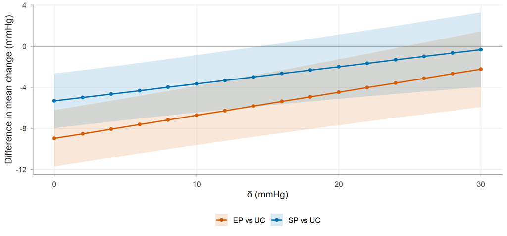

## Try it

Workbook exercise 6: delta adjustment and tipping point.

# Informative visit timing

## KIDNEY: low eGFR brings the next visit forward

| last_low | n_gaps | mean_gap_months |
| --- | --- | --- |
| eGFR < 30 | 446 | 2.8 |
| eGFR >= 30 | 2190 | 5.4 |

- Window means over-represent sick patients (pulled down)
- Kidney failure removes the sickest (pushed up)
- A mixed model treats the **patient**, not the measurement, as the unit

## Simulation: naive means are biased, the mixed model much less

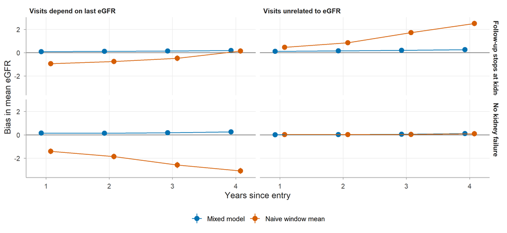

## In the KIDNEY data themselves

| year | n_obs | naive | lmm | truth |
| --- | --- | --- | --- | --- |
| 1 | 283 | 47.84 | 47.27 | 47.02 |
| 2 | 272 | 43.15 | 44.85 | 44.44 |
| 3 | 281 | 41.23 | 42.12 | 41.57 |
| 4 | 254 | 39.15 | 39.10 | 38.39 |

## Summary

- Describe the pattern; test against MCAR, never “for MAR”
- Primary analysis: likelihood-based mixed model of all observed data (valid under MAR)
- No LOCF; no completers-only primary analysis
- MI: impute by arm or with a multilevel model; pool with Rubin’s rules
- Sensitivity: delta adjustment and tipping point, with a pre-specified plausible δ
- Outcome-driven visits: avoid window means; model the patient